**Course:** STAT448-20S1

**Name:** Zhen Huang **ID:** 74093323

**Name:** Neha Thakkar **ID:** 51192498

## STAT448-Assignment 1

```r
library(e1071)
```

### Q1

#### (c) Perform the same matrix algebra calculations of part (a) using R.

```r
# Let matrix order (3x1) be response variable Y
Y <- matrix(c(5,9,13),nrow=3,ncol=1)
# Let matrix order (3x2) be explanatory variable X
x <- c(3,4,5)
X <- matrix(c(rep(1,3),x), nrow = 3, ncol = 2)
```

Perform part (a) using R, work with OLS solution to estimate coefficient $\hat{B}=(X^TX)^{-1}X^Ty$ .

```r
B <- solve(t(X)%*%(X))%*%t(X)%*%Y # calculate the coefficients vector with R code.
B
```

```
     [,1]
[1,]   -7
[2,]    4
```

Perform part (b) using R, the estimated residuals can be written: $\hat{\epsilon}=y-X\hat{B}$

```r
e <- Y - X%*%B # perform above formula with R code.
e # The output are not zero, because R uses binary decimal to represent the number, which approximately equal to zero.
```

```
              [,1]
[1,] -1.776357e-14
[2,] -1.776357e-14
[3,] -1.776357e-14
```

#### (d) Estimate the coefficients using the function lm in R.

```r
my_lm <- lm(Y~x)
my_lm
```

```
Call:
lm(formula = Y ~ x)

Coefficients:
(Intercept)            x
         -7            4
```

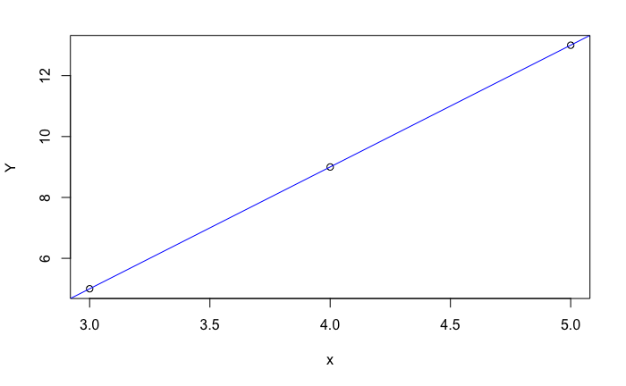

```r
plot(Y~x)
abline(my_lm,col='blue')
```

### Q2

#### (a) What happens to the coefficient estimates?

The coefficient estimates cannot be worked out, since we cannot calculate $(X_1^TX_1)^{-1}$ when $X_1=\begin{bmatrix} 1 & 2\\ 1 & 2\\ 1 & 2\end{bmatrix}$, the inverse of maxtrix $(X_1^TX_1)=\begin{bmatrix} 3 & 6\\6 & 12\end{bmatrix}$ cannot be “solved”, becuase the determinent of $(X_1^TX_1)$ is 0.

```r
x1 <- c(rep(2,3))
X1 <- matrix(c(rep(1,3),x1), nrow = 3, ncol = 2)
X1
```

```
     [,1] [,2]
[1,]    1    2
[2,]    1    2
[3,]    1    2
```

```r
det1 <- det(t(X1)%*%X) # |X'X| = 0
det1
```

```
[1] 0
```

#### (b) Please give both a statistical and geometric explanation of this situation.

When we calculated for above question, the inverse of maxtrix $(X_1^TX_1)=\begin{bmatrix} 3 & 6\\6 & 12\end{bmatrix}$ cannot be “solved”, becuase the determinent of $(X_1^TX_1)$ is 0. In another word, “It is a necessary and sufficient condition that A must be non-singular for the inverse to exist”.

The correlation coefficient cannot be calculated as well, because $\rho_{xy}=\frac{Cov(x,y)}{\sqrt{Var(x)Var(y)}}$, but $Var(x)=0$

The graph below shows that the values of y has no relationion with values of x, in which $\beta_1 \to \infty$.

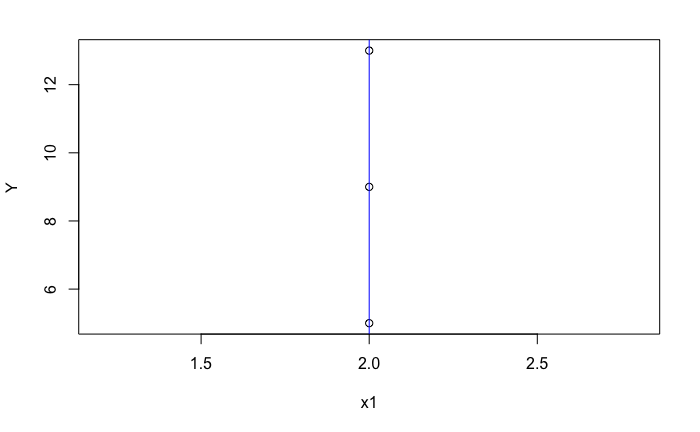

```r
plot(x1, Y) # vetor x1 is {2,2,2}
abline(v=2, col='blue')
```